# lab9

Harley Combest

2023-07-30

# Tasks

## Task 1

```r
getwd()
```

```
## [1] "E:/main/Post 06282023/Classes/Applied Statistical Methods MATH4753/lab9"
```

## Task 2

```r
myboot<-function(iter=10000,x,fun="mean",alpha=0.05,...){
#Notice where the ... is repeated in the code
n=length(x) #sample size
#Now sample with replacement
y=sample(x,n*iter,replace=TRUE) #A
# Make a matrix with all the resampled values
rs.mat=matrix(y,nr=n,nc=iter,byrow=TRUE)
xstat=apply(rs.mat,2,fun)
# xstat is a vector and will have iter values in it
ci=quantile(xstat,c(alpha/2,1-alpha/2)) #B
# Nice way to form a confidence interval
# A histogram follows
# The object para will contain the parameters used to make the histogram
para=hist(xstat,freq=FALSE,las=1,main="Histogram of Bootstrap sample
statistics",...)
#mat will be a matrix that contains the data, this is done so that I can use apply()
mat=matrix(x,nr=length(x),nc=1,byrow=TRUE)
#pte is the point estimate
#This uses whatever fun is
pte=apply(mat,2,fun)
abline(v=pte,lwd=3,col="Black")# Vertical line
segments(ci[1],0,ci[2],0,lwd=4) #Make the segment for the ci
text(ci[1],0,paste("(",round(ci[1],2),sep=""),col="Red",cex=3)
text(ci[2],0,paste(round(ci[2],2),")",sep=""),col="Red",cex=3)
# plot the point estimate 1/2 way up the density
text(pte,max(para$density)/2,round(pte,2),cex=3)
return(list(ci=ci,fun=fun,x=x))# Some output to use if necessary
}
```

Line A creates a number of iterations of random samples with replacement and assigns these to object ‘y’.

Line B creates a quantile (division of data into equal halves) on the interval alpha/2 to 1-alpha/2 of xstat and assigns it to the object ‘ci’.

It has to do that; otherwise, the sample wouldn’t be truly random in selection.

```r
set.seed(35) # This will give everyone the same sample
sam=round(rnorm(20,mean=10,sd=4),2)
unique(sample(sam,20,replace=TRUE) ) # repeat this line 5Xs
```

```
##  [1] 12.05 23.35 11.40 14.26  8.43 13.46  2.37  8.62 17.35 11.64 14.76  9.82
```

I see dead people, and I can’t explain it.

But in regards to the lab, I see a series of random numbers: looks like three random intervals followed by a random number and then two random intervals followed by another random number (perhaps a single point).

```r
unique(sample(sam,20,replace=FALSE) ) # repeat this line 5Xs
```

```
##  [1]  8.43 14.26  7.75  2.89 12.05  8.62  9.82 17.35 10.53 23.35  6.93 11.40
## [13]  2.37  8.00 11.78 16.69  9.86 11.64 14.76 13.46
```

About the same thing I saw earlier but more points.

```r
#sample(sam,21,replace=FALSE)
```

An error is obtained as one can’t take a sample larger than the population which is what happens when we do so without replacement and size 21.

## Task 3

```r
layout(matrix(1:4,nr=2,nc=2,byrow=TRUE))

set.seed(39); sam1=rnorm(25,mean=25,sd=10)
myboot(iter=10000,x=sam1,alpha=0.05)
```

```
## $ci
##     2.5%    97.5%
## 21.29544 26.44594
##
## $fun
## [1] "mean"
##
## $x
##  [1] 23.14434 12.70757 20.72797 19.04018 29.67324 29.21639 14.78348 18.77523
##  [9] 33.37002 34.61627 26.04230 24.40206 32.03731 17.45030 19.54464 20.45388
## [17] 23.83394 30.47815 25.79640 22.67536 10.27711 26.77487 37.10044 21.59809
## [25] 22.50625
```

```r
set.seed(30); sam2=rchisq(20,df=3)
myboot(iter=10000,x=sam2,alpha=0.05)
```

```
## $ci
##     2.5%    97.5%
## 2.058324 3.872860
##
## $fun
## [1] "mean"
##
## $x
##  [1] 0.2531032 1.6194423 5.3578133 7.3134789 0.1194100 5.0344239 5.8189991
##  [8] 4.3689673 1.6690814 3.2533362 0.9050305 2.5730754 1.9610329 2.9675027
## [15] 1.5722396 1.6959031 1.9261106 3.9198072 6.0919801 0.4082447
```

```r
set.seed(40); sam3=rgamma(30,shape=2,scale=3)
myboot(iter=10000,x=sam3,alpha=0.05)
```

```
## $ci
##     2.5%    97.5%
## 5.109096 7.955578
##
## $fun
## [1] "mean"
##
## $x
##  [1]  6.4265012  6.5077401  1.8958495  5.3836641  1.4179366  0.7925928
##  [7]  8.0380097 14.7293204  5.2917468  2.7989621  7.9632983  2.8733832
## [13]  7.4419824  2.2828464  5.9877646 12.9354365  1.4996069  1.7478044
## [19] 12.3674161  8.4093535 10.2053201  8.0243948  6.5178039  7.9118846
## [25]  1.6924333 10.7938057  5.7341134 15.1533278  3.8545321  8.1861897
```

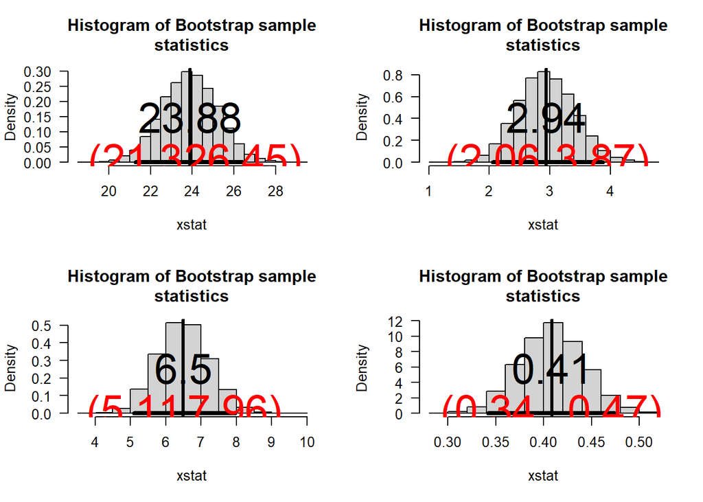

```
## $ci
##      2.5%     97.5%
## 0.3420448 0.4747873
##
## $fun
## [1] "mean"
##
## $x
##  [1] 0.4325491 0.3899825 0.1714409 0.3068918 0.4920588 0.5129946 0.1974398
##  [8] 0.3533577 0.1343329 0.3751208 0.6722481 0.5946901 0.3788602 0.6467397
## [15] 0.5914547 0.4476104 0.2407876 0.3877302 0.5336340 0.3074436
```

```r
set.seed(10); sam4=rbeta(20,shape1=3,shape2=4)
myboot(iter=10000,x=sam4,alpha=0.05)
```

```r
layout(matrix(1:4,nr=2,nc=2,byrow=TRUE))

set.seed(39); sam1=rnorm(25,mean=25,sd=10)
myboot(iter=10000,x=sam1,alpha=0.20)
```

```
## $ci
##      10%      90%
## 22.20145 25.55677
##
## $fun
## [1] "mean"
##
## $x
##  [1] 23.14434 12.70757 20.72797 19.04018 29.67324 29.21639 14.78348 18.77523
##  [9] 33.37002 34.61627 26.04230 24.40206 32.03731 17.45030 19.54464 20.45388
## [17] 23.83394 30.47815 25.79640 22.67536 10.27711 26.77487 37.10044 21.59809
## [25] 22.50625
```

```r
set.seed(30); sam2=rchisq(20,df=3)
myboot(iter=10000,x=sam2,alpha=0.20)
```

```
## $ci
##      10%      90%
## 2.345879 3.544801
##
## $fun
## [1] "mean"
##
## $x
##  [1] 0.2531032 1.6194423 5.3578133 7.3134789 0.1194100 5.0344239 5.8189991
##  [8] 4.3689673 1.6690814 3.2533362 0.9050305 2.5730754 1.9610329 2.9675027
## [15] 1.5722396 1.6959031 1.9261106 3.9198072 6.0919801 0.4082447
```

```r
set.seed(40); sam3=rgamma(30,shape=2,scale=3)
myboot(iter=10000,x=sam3,alpha=0.20)
```

```
## $ci
##      10%      90%
## 5.565593 7.447238
##
## $fun
## [1] "mean"
##
## $x
##  [1]  6.4265012  6.5077401  1.8958495  5.3836641  1.4179366  0.7925928
##  [7]  8.0380097 14.7293204  5.2917468  2.7989621  7.9632983  2.8733832
## [13]  7.4419824  2.2828464  5.9877646 12.9354365  1.4996069  1.7478044
## [19] 12.3674161  8.4093535 10.2053201  8.0243948  6.5178039  7.9118846
## [25]  1.6924333 10.7938057  5.7341134 15.1533278  3.8545321  8.1861897
```

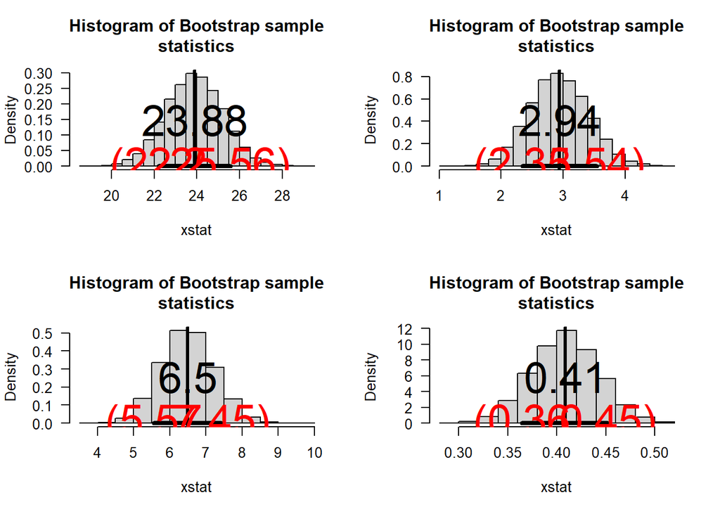

```
## $ci
##       10%       90%
## 0.3645477 0.4524504
##
## $fun
## [1] "mean"
##
## $x
##  [1] 0.4325491 0.3899825 0.1714409 0.3068918 0.4920588 0.5129946 0.1974398
##  [8] 0.3533577 0.1343329 0.3751208 0.6722481 0.5946901 0.3788602 0.6467397
## [15] 0.5914547 0.4476104 0.2407876 0.3877302 0.5336340 0.3074436
```

```r
set.seed(10); sam4=rbeta(20,shape1=3,shape2=4)
myboot(iter=10000,x=sam4,alpha=0.20)
```

## Task 4

```r
myboot2<-function(iter=10000,x,fun="mean",alpha=0.05,cx=1.5,...){  #Notice where the ... is repeated in the code
n=length(x)   #sample size

y=sample(x,n*iter,replace=TRUE)
rs.mat=matrix(y,nr=n,nc=iter,byrow=TRUE)
xstat=apply(rs.mat,2,fun) # xstat is a vector and will have iter values in it

ci=quantile(xstat,c(alpha/2,1-alpha/2))# Nice way to form a confidence interval
# A histogram follows
# The object para will contain the parameters used to make the histogram
para=hist(xstat,freq=FALSE,las=1,
main=paste("Histogram of Bootstrap sample statistics","\n","alpha=",alpha," iter=",iter,sep=""),
...)

#mat will be a matrix that contains the data, this is done so that I can use apply()
mat=matrix(x,nr=length(x),nc=1,byrow=TRUE)

#pte is the point estimate
#This uses whatever fun is
pte=apply(mat,2,fun)
abline(v=pte,lwd=3,col="Black")# Vertical line
segments(ci[1],0,ci[2],0,lwd=4)      #Make the segment for the ci
text(ci[1],0,paste("(",round(ci[1],2),sep=""),col="Red",cex=cx)
text(ci[2],0,paste(round(ci[2],2),")",sep=""),col="Red",cex=cx)

# plot the point estimate 1/2 way up the density
text(pte,max(para$density)/2,round(pte,2),cex=cx)

invisible(list(ci=ci,fun=fun,x=x))# Some output to use if necessary
}
```

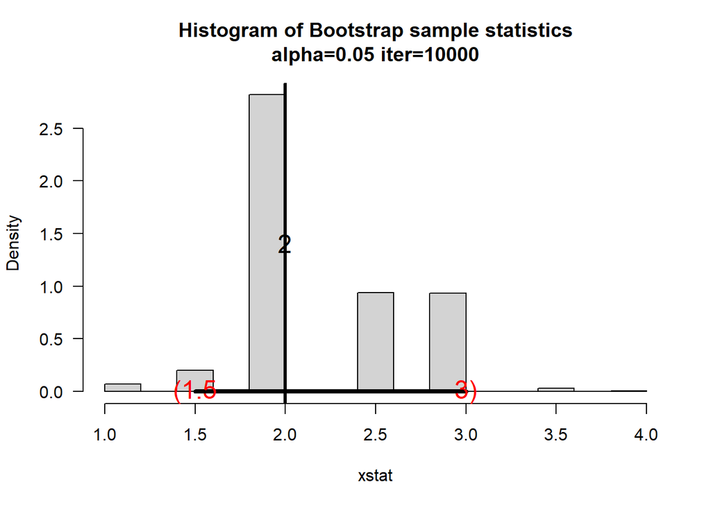

```r
sam=c(1,1,1,2,2,2,2,3,3,3,4,4)
myboot2(iter=10000,x=sam,fun="median",alpha=0.05,cx=1.5)
```

[figure not shown]

```r
n=length(sam)   #sample size

y=sample(sam,n*10000,replace=TRUE)
rs.mat=matrix(y,nr=n,nc=10000,byrow=TRUE)
xstat=apply(rs.mat,2,"median")
barplot(xstat)
```

The bootstrap interval estimate for the median is (1.5, 3).

## Task 5

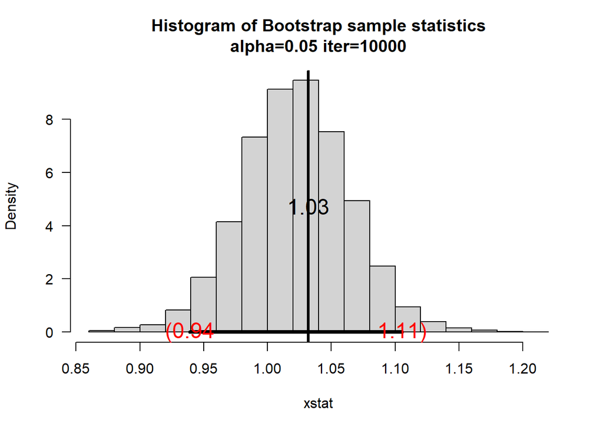

```r
#layout(matrix(1:16,nr=4,nc=4,byrow=TRUE))

meanOverMedian<-function(x){
  mean=mean(x)
  median=median(x)
  y=mean/median
  return(y)
}

set.seed(39); sam1=rnorm(25,mean=25,sd=10)
myboot2(iter=10000,x=sam1,fun="meanOverMedian",alpha=0.05)
```

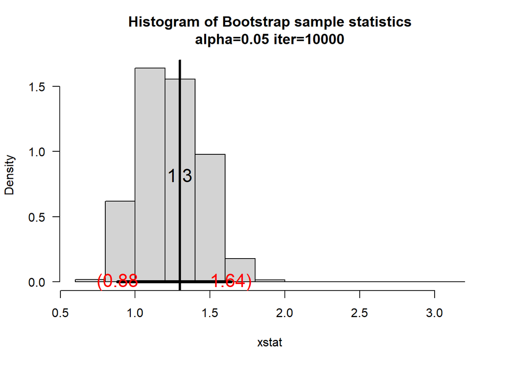

```r
set.seed(30); sam2=rchisq(20,df=3)
myboot2(iter=10000,x=sam2,fun="meanOverMedian",alpha=0.05)
```

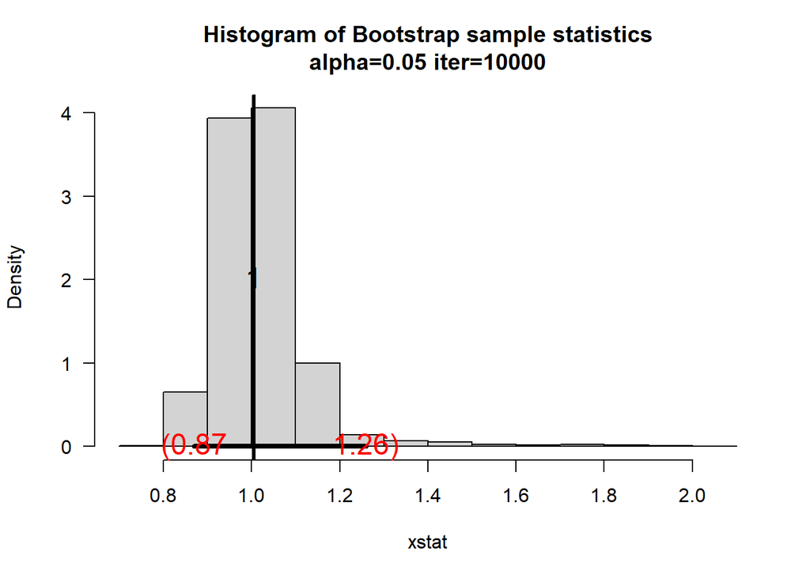

```r
set.seed(40); sam3=rgamma(30,shape=2,scale=3)
myboot2(iter=10000,x=sam3,fun="meanOverMedian",alpha=0.05)
```

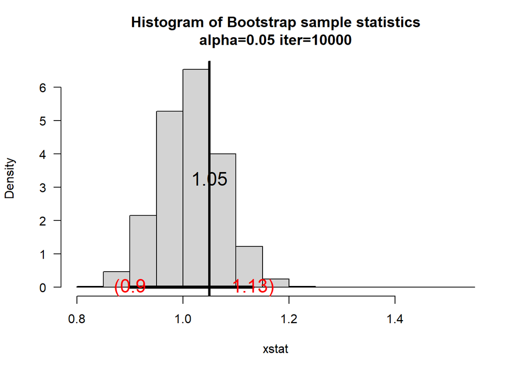

```r
set.seed(10); sam4=rbeta(20,shape1=3,shape2=4)
myboot2(iter=10000,x=sam4,fun="meanOverMedian",alpha=0.05)
```

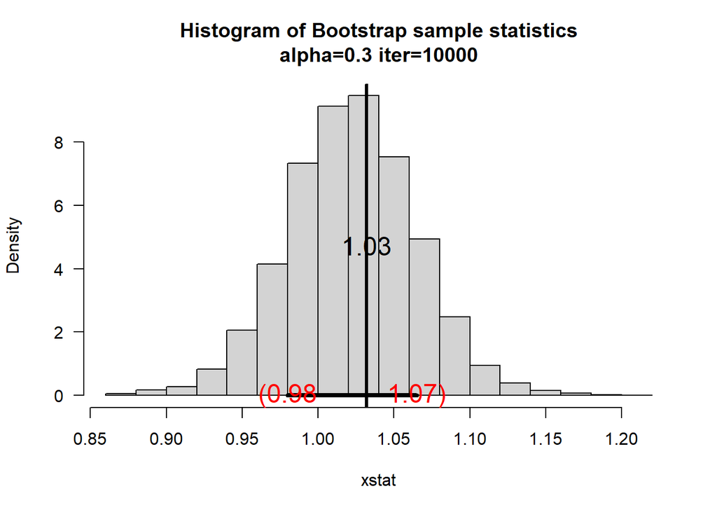

```r
set.seed(39); sam1=rnorm(25,mean=25,sd=10)
myboot2(iter=10000,x=sam1,fun="meanOverMedian",alpha=0.30)
```

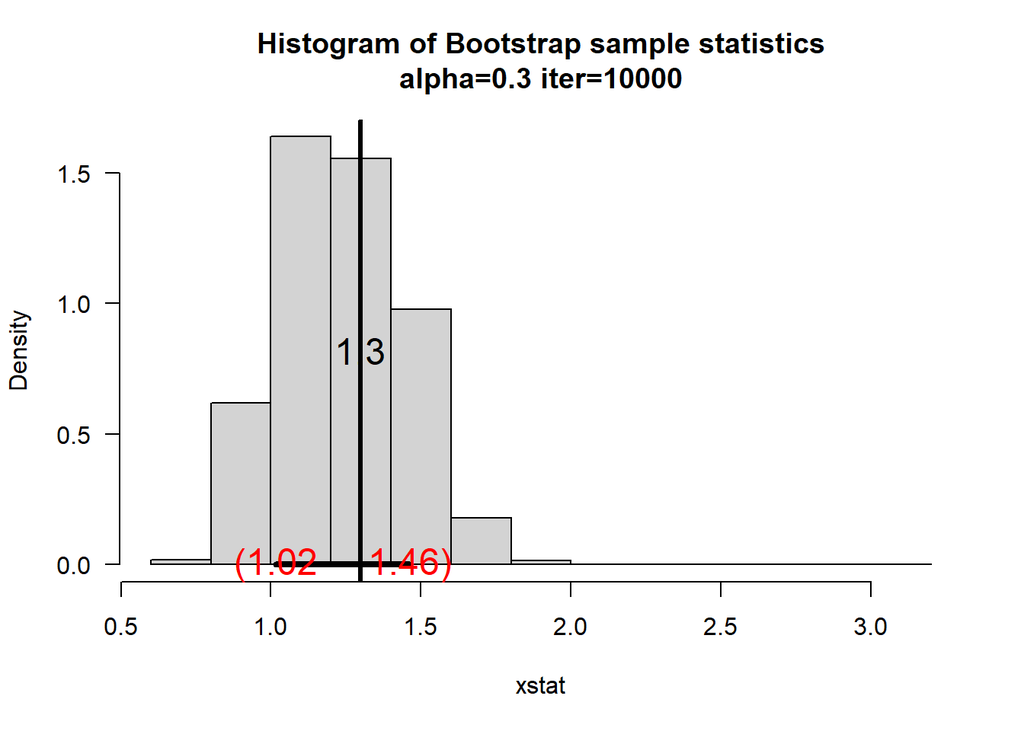

```r
set.seed(30); sam2=rchisq(20,df=3)
myboot2(iter=10000,x=sam2,fun="meanOverMedian",alpha=0.30)
```

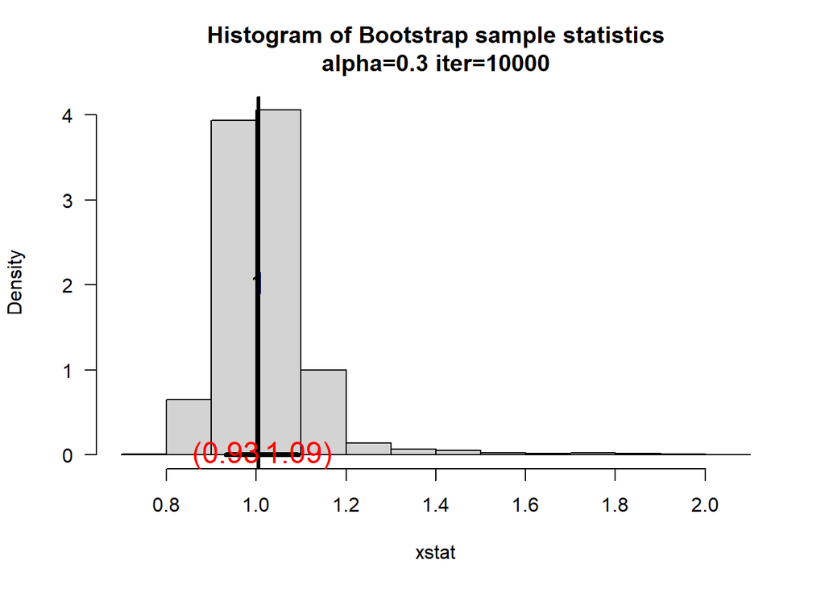

```r
set.seed(40); sam3=rgamma(30,shape=2,scale=3)
myboot2(iter=10000,x=sam3,fun="meanOverMedian",alpha=0.30)
```

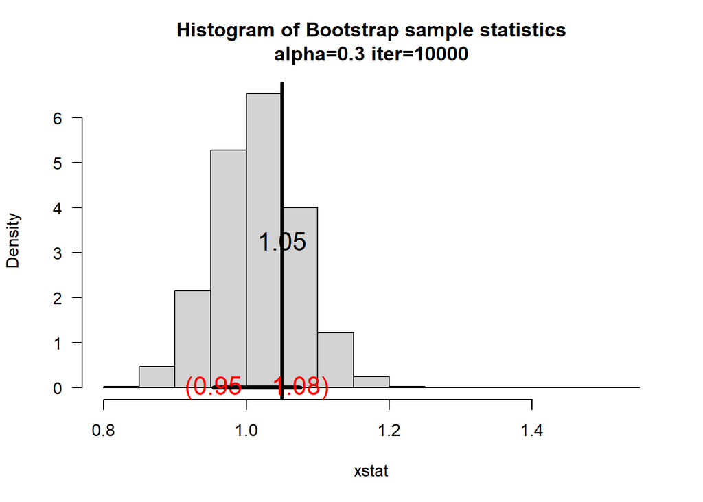

```r
set.seed(10); sam4=rbeta(20,shape1=3,shape2=4)
myboot2(iter=10000,x=sam4,fun="meanOverMedian",alpha=0.30)
```

## Task 6

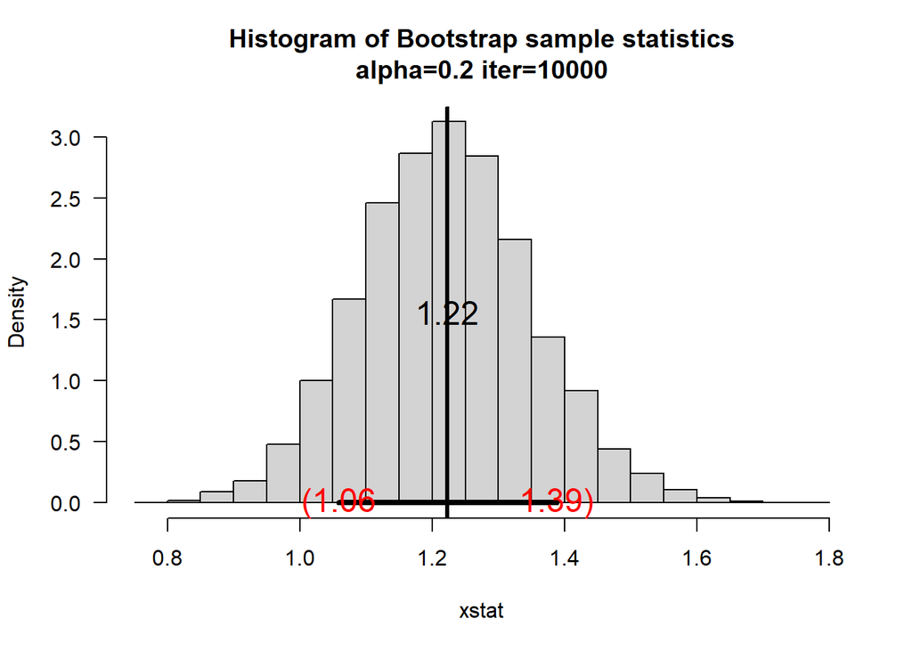

```r
set.seed(39); sam1=rexp(n = 50)
myboot2(iter=10000,x=sam1,fun="mean",alpha=0.20)
```

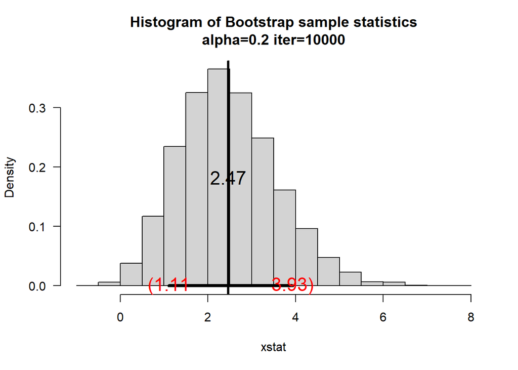

```r
set.seed(30); sam2=rcauchy(n = 50)
myboot2(iter=10000,x=sam2,fun="mean",alpha=0.20)
```

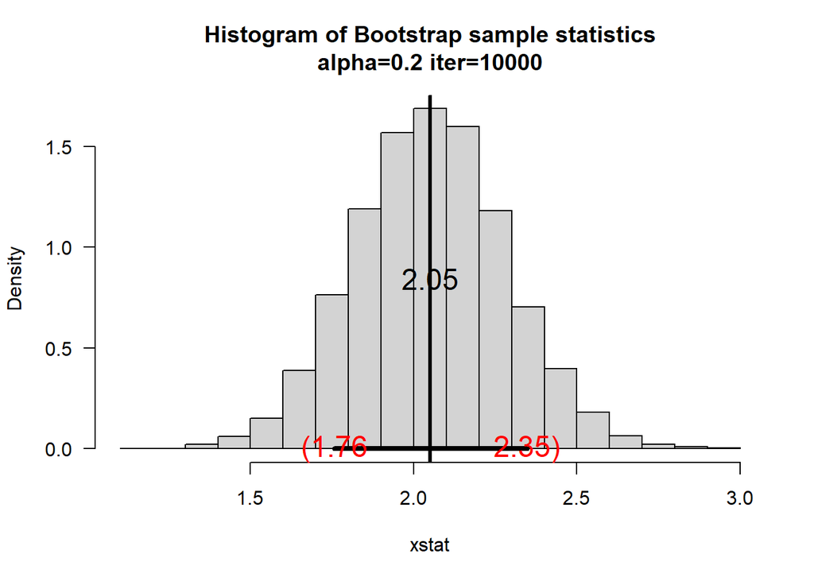

```r
set.seed(40); sam3=rweibull(n=50,shape = 1,scale = 2)
myboot2(iter=10000,x=sam3,fun="mean",alpha=0.20)
```

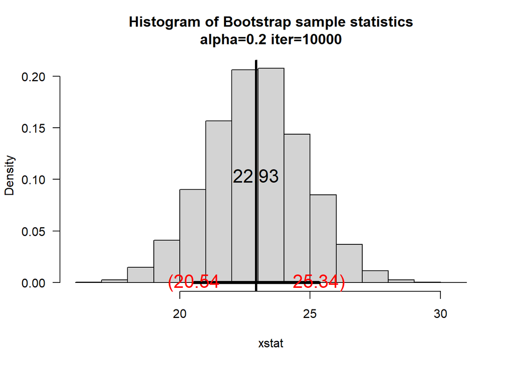

```r
set.seed(10); sam4=runif(n = 50,min = 0,max=50)
myboot2(iter=10000,x=sam4,fun="mean",alpha=0.20)
```

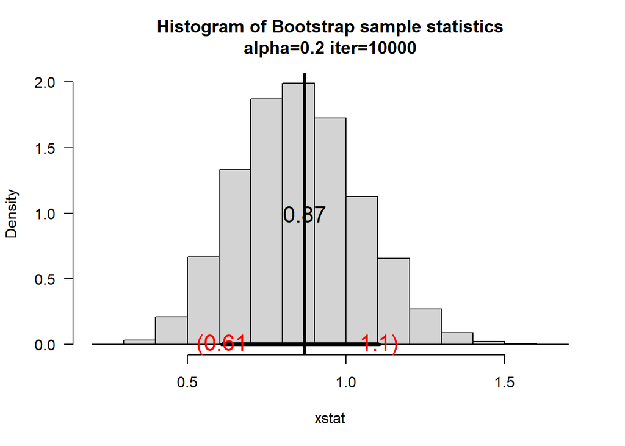

```r
set.seed(39); sam1=rexp(n = 50)
myboot2(iter=10000,x=sam1,fun="var",alpha=0.20)
```

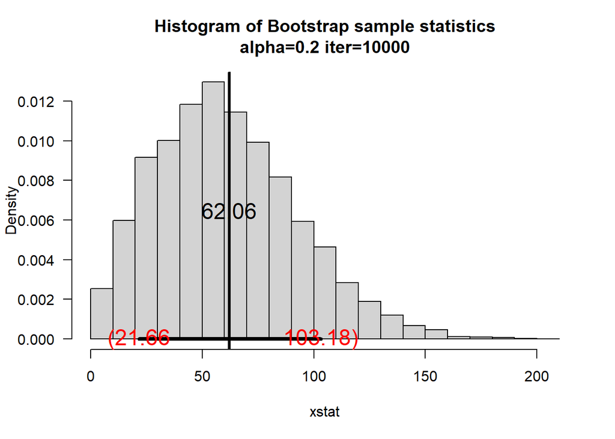

```r
set.seed(30); sam2=rcauchy(n = 50)
myboot2(iter=10000,x=sam2,fun="var",alpha=0.20)
```

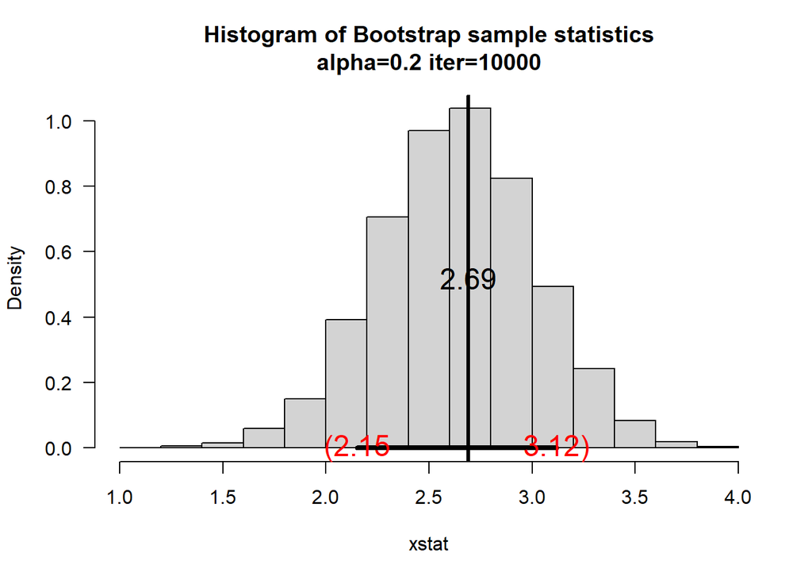

```r
set.seed(40); sam3=rweibull(n=50,shape = 1,scale = 2)
myboot2(iter=10000,x=sam3,fun="var",alpha=0.20)
```

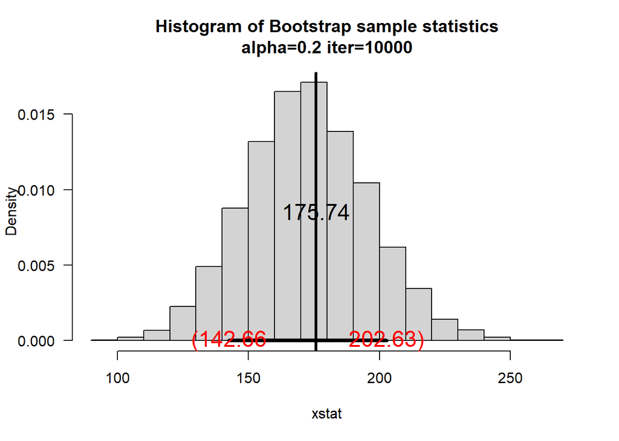

```r
set.seed(10); sam4=runif(n = 50,min = 0,max=50)
myboot2(iter=10000,x=sam4,fun="var",alpha=0.20)
```

## Task 7

```r
myboot3<-function(iter=10000,x,fun="mean",alpha=0.05,...){
#Notice where the ... is repeated in the code
n=length(x) #sample size
#Now sample with replacement
y=sample(x,n*iter,replace=TRUE) #A
# Make a matrix with all the resampled values
rs.mat=matrix(y,nr=n,nc=iter,byrow=TRUE)
xstat=apply(rs.mat,2,fun)
# xstat is a vector and will have iter values in it
ci= mean(y) + c(-sd(y),sd(y)) #B
# Nice way to form a confidence interval
# A histogram follows
# The object para will contain the parameters used to make the histogram
para=hist(xstat,freq=FALSE,las=1,main="Histogram of Bootstrap sample
statistics",...)
#mat will be a matrix that contains the data, this is done so that I can use apply()
mat=matrix(x,nr=length(x),nc=1,byrow=TRUE)
#pte is the point estimate
#This uses whatever fun is
pte=apply(mat,2,fun)
abline(v=pte,lwd=3,col="Black")# Vertical line
segments(ci[1],0,ci[2],0,lwd=4) #Make the segment for the ci
text(ci[1],0,paste("(",round(ci[1],2),sep=""),col="Red",cex=3)
text(ci[2],0,paste(round(ci[2],2),")",sep=""),col="Red",cex=3)
# plot the point estimate 1/2 way up the density
text(pte,max(para$density)/2,round(pte,2),cex=3)
return(list(ci=ci,fun=fun,x=x))# Some output to use if necessary
}
```

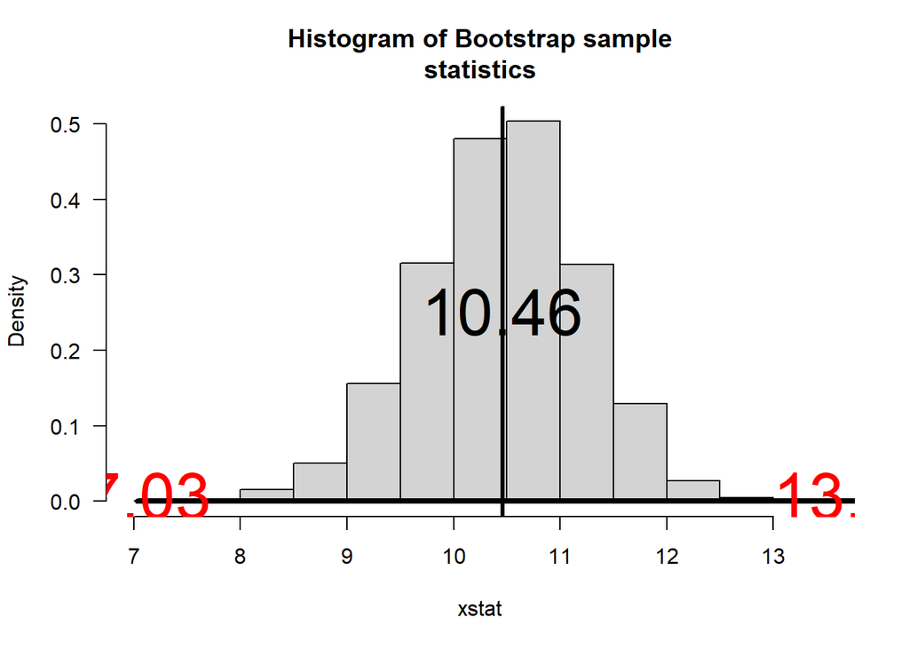

```
## $ci
## [1]  7.033796 13.865232
##
## $fun
## [1] "mean"
##
## $x
##  [1] 15.743750  9.011543  8.487107 12.302301  8.274762 10.033130 14.601905
##  [8] 11.648501 13.546594 13.330691  9.641557  6.760229  6.716014 13.997038
## [15]  9.458889 10.143532  1.155378 11.836486  7.832403 14.664414
```

```r
set.seed(68); sam5=rnorm(20,mean=10,sd=4)
myboot3(iter=10000,x=sam5,alpha=0.20)#I used mean and standard deviation
```

```r
myboot4<-function(iter=10000,x,fun="mean",alpha=0.05,...){
#Notice where the ... is repeated in the code
n=length(x) #sample size
#Now sample with replacement
y=sample(x,n*iter,replace=TRUE) #A
# Make a matrix with all the resampled values
rs.mat=matrix(y,nr=n,nc=iter,byrow=TRUE)
xstat=apply(rs.mat,2,fun)
# xstat is a vector and will have iter values in it
zScore=qnorm(1-alpha/2,mean=0,sd=1)
otherThing=(sd(y)/sqrt(n))

ci= mean(y) + c(-(zScore*otherThing),zScore*otherThing) #B
# Nice way to form a confidence interval
# A histogram follows
# The object para will contain the parameters used to make the histogram
para=hist(xstat,freq=FALSE,las=1,main="Histogram of Bootstrap sample
statistics",...)
#mat will be a matrix that contains the data, this is done so that I can use apply()
mat=matrix(x,nr=length(x),nc=1,byrow=TRUE)
#pte is the point estimate
#This uses whatever fun is
pte=apply(mat,2,fun)
abline(v=pte,lwd=3,col="Black")# Vertical line
segments(ci[1],0,ci[2],0,lwd=4) #Make the segment for the ci
text(ci[1],0,paste("(",round(ci[1],2),sep=""),col="Red",cex=3)
text(ci[2],0,paste(round(ci[2],2),")",sep=""),col="Red",cex=3)
# plot the point estimate 1/2 way up the density
text(pte,max(para$density)/2,round(pte,2),cex=3)
return(list(ci=ci,fun=fun,x=x))# Some output to use if necessary
}
```

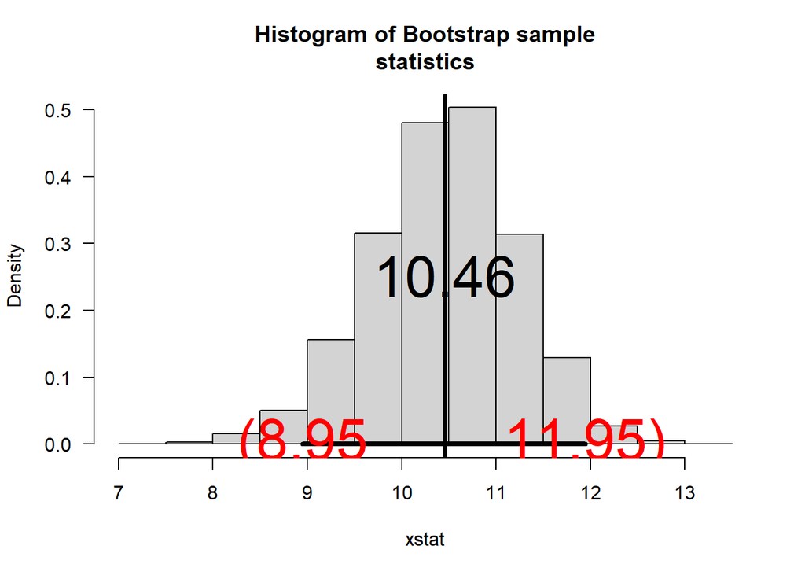

```
## $ci
## [1]  8.952537 11.946491
##
## $fun
## [1] "mean"
##
## $x
##  [1] 15.743750  9.011543  8.487107 12.302301  8.274762 10.033130 14.601905
##  [8] 11.648501 13.546594 13.330691  9.641557  6.760229  6.716014 13.997038
## [15]  9.458889 10.143532  1.155378 11.836486  7.832403 14.664414
```

```r
set.seed(68); sam6=rnorm(20,mean=10,sd=4)
myboot4(iter=10000,sam6,fun="mean",alpha=0.05)
```

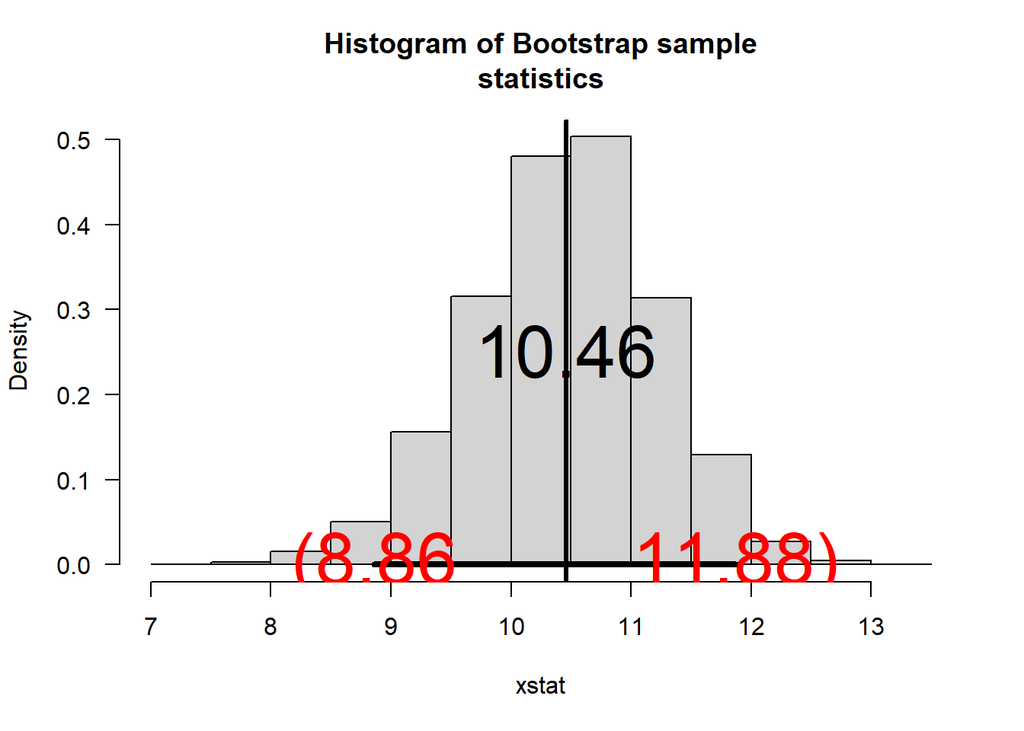

```
## $ci
##      2.5%     97.5%
##  8.862478 11.878680
##
## $fun
## [1] "mean"
##
## $x
##  [1] 15.743750  9.011543  8.487107 12.302301  8.274762 10.033130 14.601905
##  [8] 11.648501 13.546594 13.330691  9.641557  6.760229  6.716014 13.997038
## [15]  9.458889 10.143532  1.155378 11.836486  7.832403 14.664414
```

```r
set.seed(68); sam7=rnorm(20,mean=10,sd=4)
myboot(iter=10000,sam6,fun="mean",alpha=0.05)
```

## Task 8

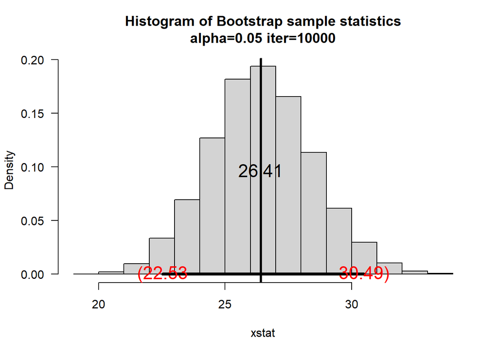

```r
fire=myPackage1::fire
myPackage1::myboot2(x=fire$DAMAGE)
```